# Pruebas de hipótesis con datos categóricos en R

Parte 1: **Pruebas en tablas r x c

Pablo Andrés Guzmán Taller R y Rmarkdown

Marzo 2022

- categorizar una variable numérica
- cambiar las etiquetas de los niveles en un factor
- cambiar el orden de los niveles en un factor
- reagrupar los niveles de un factor
- usar lo anterior para apoyar el diseño de gráficos

Para la mayoría de actividades usaremos comandos de **forcats** un paquete del **tidyverse** especializado en manipular factores.

## Librerías

```r
library(vcd)
library(tidyverse)
library(MASS)
```

## Ejemplo 1: Fuentes de fibra e hinchazón estómacal

### Problema y datos

En un estudio se dió de comer a los participantes un nuevo tipo de galletas enriquecidas con fibra. Los sujetos estuvieron asignados a uno de cuatro tipos de galleta: sin fibra, con fibra a base de salvado, con fibra a base de goma o con fibra base de ambos, salvado y goma. Al poco tiempo luego de la ingesta, se le pidió a los participantes que reportaran si tuvieron síntomas de hinchazón estómacal como una de cuatro categorías: ninguna, baja, media o alta hinchazón. Los datos para los 48 sujetos se encuentran en el archivo datFibra.csv de manera agrupada en formato largo. Use el siguiente código para importar los datos:

```r
datFibra <- read.csv(file = "datFibra.csv")
str(datFibra)  # esctructura de la tabla
```

```
'data.frame':   16 obs. of  5 variables:
 $ fibra    : chr  "ninguna" "salvado" "goma" "ambas" ...
 $ salvado  : chr  "no" "si" "no" "si" ...
 $ goma     : chr  "no" "no" "si" "si" ...
 $ hinchazon: chr  "ninguno" "ninguno" "ninguno" "ninguno" ...
 $ n        : int  6 7 2 2 4 4 2 5 2 1 ...
```

El propósito del ejercicio es evaluar si los síntomas de hinchazón están **asociados** a las categorías de `fibra` en los cuatro tipos de galleta.

### Tabla de contingencia

Un tabla de contingencia es el punto de partida del análisis. Antes revisemos los niveles (y su orden) de las variables `fibra` e `hinchazon`:

```r
factor(datFibra$fibra) %>% levels()      # niveles de fibra
```

```
[1] "ambas"   "goma"    "ninguna" "salvado"
```

```r
factor(datFibra$hinchazon) %>% levels()  # niveles de hinchazon
```

```
[1] "alto"    "bajo"    "medio"   "ninguno"
```

Modificamos el orden de los niveles en ambas variables:

```r
datFibra <- mutate(datFibra,
  fibra     = fct_relevel(fibra, "ninguna", "goma", "salvado"),
  hinchazon = fct_relevel(hinchazon, "ninguno", "bajo", "medio")
)
```

**Ejercicios**

1. Realice la siguiente tabla de contingencia:

   ```
            hinchazon
   fibra     ninguno bajo medio alto Sum
     ninguna       6    4     2    0  12
     goma          2    2     3    5  12
     salvado       7    4     1    0  12
     ambas         2    5     3    2  12
     Sum          17   15     9    7  48
   ```

   **Código solución**

   ```r
    # Tabla de contigencia con totales marginales
    xtabs(n ~ fibra + hinchazon, data = datFibra) %>%
      addmargins()
   ```

2. Realice la siguiente tabla de contigencia:

   ```
            hinchazon
   fibra     ninguno  bajo medio  alto   Sum
     ninguna    50.0  33.3  16.7   0.0 100.0
     goma       16.7  16.7  25.0  41.7 100.0
     salvado    58.3  33.3   8.3   0.0 100.0
     ambas      16.7  41.7  25.0  16.7 100.0
   ```

   **Código solución**

   ```r
    # Tabla de contigencia de frec. relativas condicionales
    # con totales marginales
    xtabs(n ~ fibra + hinchazon, data = datFibra) %>%
      prop.table(margin = 1) %>%
      addmargins(2) %>%
      round(3)*100
   ```

### Gráfico exploratorio

El siguiente gráfico muestra la frecuencia condicional de las categorías de `hinchazon` de acuerdo a la `fibra`:

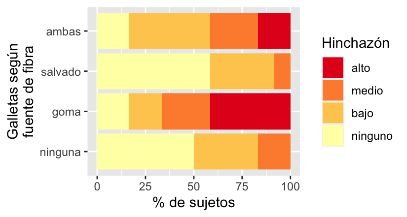

**Ejercicios**

- De acuerdo al gráfico, ¿la respuesta del hinchazón estómacal parece ser **independiente** del tipo de fibra en la galleta? Explique
- Escriba código **R** que genere el gráfico.

**Código solución**

```r
# Grafico de barras apiladas con frec. condicionales
xtabs(n ~ fibra + hinchazon, data = datFibra) %>%
  prop.table(margin = 1) %>%
  as.data.frame() %>%
  ggplot(aes(y = fibra, x = Freq*100, fill = fct_rev(hinchazon))) +
  geom_col() +
  scale_fill_brewer(direction = -1, palette = "YlOrRd") +
  labs(fill = "Hinchazón", y = "Galletas según\nfuente de fibra",
       x = "% de sujetos")
```

## Prueba de hipótesis

La prueba chi-cuadrado permite probar:

$$\begin{eqnarray*}
H_0: & & \text{La fibra y el hinchazon son independientes}\\
H_1: & & \text{La fibra y el hinchazon no son independientes (están asociadas)}\\
\end{eqnarray*}$$

Esta prueba se ejecuta en **R** con alguno de los siguientes comandos:

[output not shown]

### Ejecución de la prueba

```r
# Se guarda tabla de contigencia
d <- xtabs(n ~ fibra + hinchazon, data = datFibra)

# Desde comando: chisq.test ----
r <- chisq.test(d, correct = F); r
```

```
    Pearson's Chi-squared test

data:  d
X-squared = 16.943, df = 9, p-value = 0.04962
```

```r
# Desde comando: summary ----
summary(d)
```

```
Call: xtabs(formula = n ~ fibra + hinchazon, data = datFibra)
Number of cases in table: 48
Number of factors: 2
Test for independence of all factors:
    Chisq = 16.943, df = 9, p-value = 0.04962
    Chi-squared approximation may be incorrect
```

```r
# Desde comanado assocstats ----
assocstats(d)
```

```
                    X^2 df P(> X^2)
Likelihood Ratio 18.880  9 0.026230
Pearson          16.943  9 0.049621

Phi-Coefficient   : NA
Contingency Coeff.: 0.511
Cramer's V        : 0.343
```

## Para saber más

### Estadístico de prueba Chi-cuadrado

El estadístico de prueba Chi-cuadrado en una prueba de independencia para una tabla de contingencia de $r$ filas $\times$ $c$ columnas está dado por:

$$\begin{equation}
X^2 = \sum_{i = 1}^r\sum_{j = 1}^c \dfrac{(n_{ij} - e_{ij})^2}{e_{ij}}
\tag{1}
\end{equation}$$

donde $n_{ij}$ es la frecuencia absoluta observada en la fila $i$ y columna $j$ de la tabla de contingencia y $e_{ij}$ es la frecuencia absoluta esperada para la fila $i$ y la columna $j$ bajo la **hipótesis nula** de que existe **independencia** entre las variables.

Si $\pi_{ij}$ es la proporción poblacional en la celda $\{i,j\}$ de la tabla y $\pi_{i\cdot}$ y $\pi_{\cdot j}$ son las proporciones poblacionales marginales de la fila $i$ y columna $j$ respectivamente, entonces la **hipótesis nula** de **independencia** se puede escribir como:

$$H_0: \pi_{ij} = \pi_{i\cdot} \times \pi_{\cdot j}$$

Con esta idea, la frecuencia absoluta esperada bajo H<sub>0</sub> en la celda $\{i,j\}$ se obtiene como :

$$\begin{equation}
e_{ij} = \dfrac{n_{i\cdot} \times n_{\cdot j} }{n} = \dfrac{[\text{Total Fila } i] \times [\text{Total Col } j] }{[\text{Gran total}]}
\tag{2}
\end{equation}$$

donde:

$$\begin{eqnarray*}
n_{i\cdot} = \sum_{j = 1}^c n_{ij} & \quad \text{total o suma de las frec. absolutas observadas en la fila } i \\
n_{\cdot j} = \sum_{i = 1}^r n_{ij} & \quad \text{total o suma de las frec. absolutas observadas en la columna } j \\
n = \sum_{i = 1}^r\sum_{j = 1}^c n_{ij} & \quad \text{total o suma de todas las frec. absolutas observadas o Gran total}
\end{eqnarray*}$$

El estadístico $X^2$ sigue una distribución Chi-cuadrado con $(r-1)(c-1)$ grados de libertad si la hipótesis nula de independencia es cierta.

### Medidas de asociación desde la prueba chi-cuadrado

Existen tres coeficientes derivados del estadístico de prueba Chi-cuadrado que permiten medir la asociación entre las variables implicadas en la tabla de contingencia.

- Coeficiente de contingencia
- V de Cramer
- Coeficiente Phi

A continuación se describen estos coeficientes.